# **Targeting A Housing Subsidy**

Assignment 05 - Public Policy Analytics | Jarred Randall

# **MOTIVATION**

The Emil City Department of Housing and Community Development extends a home repair tax credit program to eligible homeowners. The program spans nearly two decades and historically, homeowners have leveraged this credit to successfully boost their property values by an average of $10,000. This has resulted in neighboring properties substantially increasing in value, totaling a premium of $56,000.

Typically, however, not all eligible homeowners request the credit. The Department of Housing and Community Development finds the conversion rate minimal - perhaps a result of randomly contacting eligible homeowners. The cost of marketing each credit is $2,850 while the department must also spend an additional $5,000 per credit, since this is the amount of the subsidy granted.

Consequently, this cost-benefit analysis intends to steer the Department of Housing and Community Development towards a more precise, intentional program. To guide allocation of funds and increase participation in the credit program, our model aims to inform productive outreach for homeowners genuinely interested in the subsidy. By leveraging our insights regarding utilization of credits, we ultimately uncover subsidy eligibility centered around two desired outcomes: cost optimization and increased participation.

# **EXPLORATION**

We conduct our analysis through historical campaign records. These records provide a detailed view about traits of homeowners and their utilization of the repair credit. We start with the continuous features collected at the time of the campaign: age, unemployment rate, consumer price index, consumer confidence index, inflation rate, and annual home repair expenditure. Additional data included is the number of contacts during the campaign; the number of contacts prior to the campaign; and the days since last contacted for the previous program.

Interestingly, the variables with weak correlation to credit utilization are age, consumer price index, consumer confidence index, and annual home repair expenditure. We, however, note a correlation using the unemployment and inflation rates; the number of contacts during the campaign; the number of contacts prior to the campaign; and the days since last contacted for the previous program.

Homeowners who were contacted previously and recently show greatest susceptibility to the subsidy offer. Furthermore, they were more inclined to accept the offer when contacted during periods of low inflation, perhaps indicating a desire to invest in repairs during periods of economic stability. Further, when unemployment rates are lower, homeowners are also inclined to accept the offer. Stability and disposable income could be key to influencing the likelihood of offer acceptance - highlighting the importance of economic conditions in homeowner decision-making.

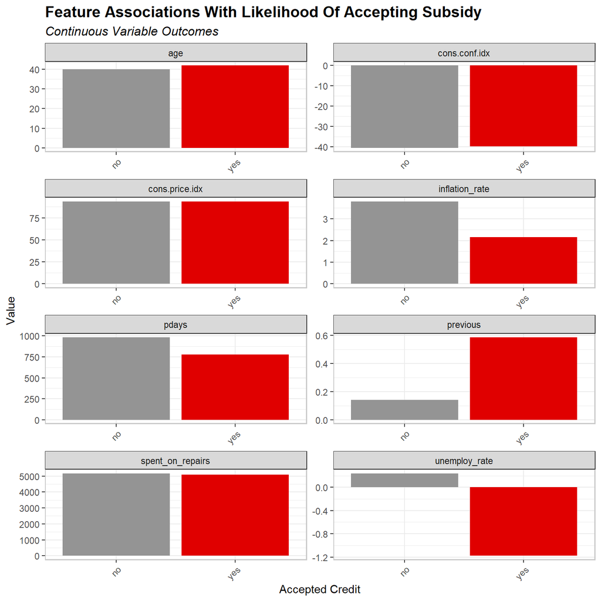

```r
housingsubsidy %>%
  dplyr::select(y, previous, age, cons.price.idx, cons.conf.idx, inflation_rate, spent_on_repairs, unemploy_rate,  previous, pdays) %>%
  gather(Variable, value, -y) %>%
  ggplot(aes(y, value, fill=y)) +
  geom_bar(position = "dodge", stat = "summary", fun = "mean") +
  facet_wrap(~Variable, scales = "free", ncol = 2) +
  scale_fill_manual(values = paletteV4) +
  labs(x="Accepted Credit", y="Value",
       title = "Feature Associations With Likelihood Of Accepting Subsidy",
       subtitle = "Continuous Variable Outcomes") +
  theme_bw() +
  theme(legend.position = "none",
        axis.text.x = element_text(angle = 45, hjust = 1),
        plot.subtitle = element_text(size = 12,face = "italic"),
        plot.title = element_text(size = 14.5, face = "bold"),
        panel.background = element_blank(),
        panel.border = element_rect(colour = "#C8C8C8", fill=NA, linewidth =0.8))
```

The majority of homeowners with mortgages do not take the credit. Similarly, a significant number of homeowners with tax bill in Philadelphia chose not to take advantage of the subsidies. This might suggest a negative correlation between these variables and subsidy utilization. However, it’s important to note that over 75% of homeowners in the dataset declined the credit. Further, individuals with a lien on their home are also more likely to make use of the credit in contrast to those without a lien on their property.

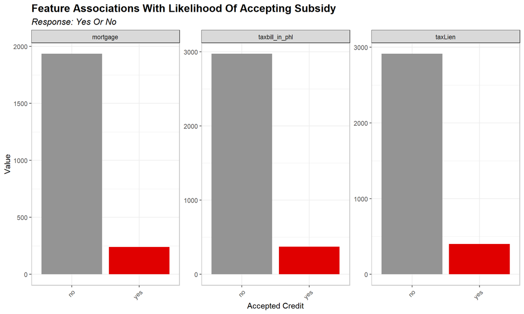

```r
housingsubsidy %>%
  dplyr::select(y, mortgage, taxbill_in_phl, taxLien) %>%
  gather(Variable, value, -y) %>%
  count(Variable, value, y) %>%
  ggplot(aes(y, n, fill=y)) +
  geom_bar(position = "dodge", stat = "identity") +  # Specifying stat as "identity" to use raw counts
  facet_wrap(~Variable, scales = "free") +
  scale_fill_manual(values = paletteV4) +
  labs(x="Accepted Credit", y="Value",
       title = "Feature Associations With Likelihood Of Accepting Subsidy",
       subtitle = "Response: Yes Or No") +
  theme_bw() +
  theme(legend.position = "none",
        axis.text.x = element_text(angle = 45, hjust = 1),
        plot.subtitle = element_text(size = 12,face = "italic"),
        plot.title = element_text(size = 14.5, face = "bold"),
        panel.background = element_blank(),
        panel.border = element_rect(colour = "#C8C8C8", fill=NA, linewidth =0.8))
```

Lastly, we analyze the categorical variables: occupation, marital status, education attainment, method of contact, month of last contact, day of week last contacted, and previous marketing outcomes. The majority of the categorical variables demonstrate no influence on the decision of homeowners to either accept or reject the subsidy. Nonetheless, month of last contact; marital status; occupation; and method of contact prove moderately helpful finding correlation with credit utilization.

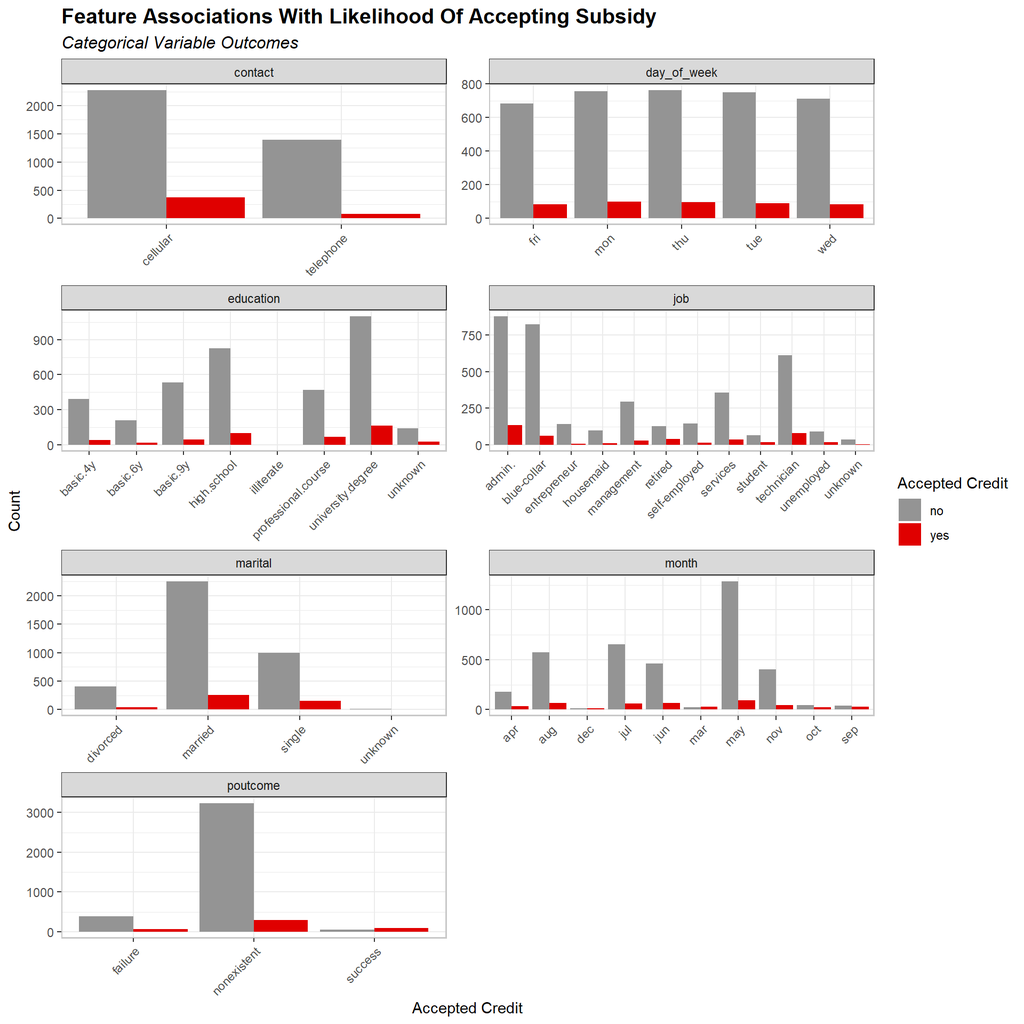

```r
housingsubsidy %>%
    dplyr::select(y, contact, job, marital, education, month, day_of_week, poutcome) %>%
    gather(Variable, value, -y) %>%
    count(Variable, value, y) %>%
      ggplot(., aes(value, n, fill = y)) +
        geom_bar(position = "dodge", stat="identity") +
        facet_wrap(~Variable, scales="free", ncol = 2) +
        scale_fill_manual(values = paletteV4) +
        labs(x="Accepted Credit", y="Count",
             title = "Feature Associations With Likelihood Of Accepting Subsidy",
             subtitle = "Categorical Variable Outcomes",
             fill = "Accepted Credit") +
        theme_bw() +
        theme(axis.text.x = element_text(angle = 45, hjust = 1),
              plot.subtitle = element_text(size = 12,face = "italic"),
              plot.title = element_text(size = 14.5, face = "bold"),
              panel.background = element_blank(),
              panel.border = element_rect(colour = "#C8C8C8", fill=NA, linewidth =0.8))
```

# **FEATURE ENGINEERING**

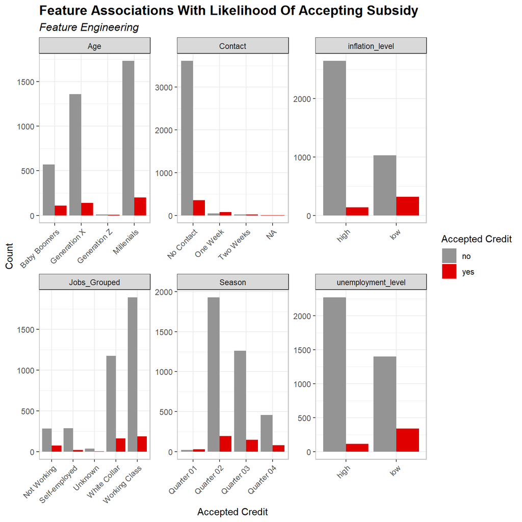

```r
# Financial Calendar, Fiscal Quarters (Q1, Q2, Q3, Q4)

housingsubsidy <-
  housingsubsidy %>%
  mutate(Season = case_when(
    month == "jan" |month == "feb" | month == "mar" ~ "Quarter 01",
    month == "apr" |month == "may" | month == "jun" ~ "Quarter 02",
    month == "jul" |month == "aug" | month == "sep" ~ "Quarter 03",
    month == "oct" |month == "nov" | month == "dec" ~ "Quarter 04"))

# Age By Generation, Split Into Four Categories

housingsubsidy <-
  housingsubsidy %>%
  mutate(Age = case_when(
    age >= 18 & age < 22  ~ "Generation Z",
    age >= 23 & age < 38  ~ "Millenials",
    age >= 39 & age < 54  ~ "Generation X",
    TRUE ~ "Baby Boomers"))

# Education Level, Split Into Four Categories

housingsubsidy <-
  housingsubsidy %>%
  mutate(Education = case_when(
    education == "basic.9y" |education == "basic.6y" | education == "basic.4y" ~ "K Through Middle",
    education == "high.school"  ~ "High School Level",
    education == "university.degree" |education == "professional.course"  ~ "Higher Education",
    education == "unknown" |education == "illiterate"  ~ "Low Or Uneducated"))

# Previous Project Contact, Split Into Five Categories

housingsubsidy <-
  housingsubsidy %>%
  mutate(Contact = case_when(pdays == 999 ~ "No Contact",
                             pdays < 7 ~ "One Week",
                             pdays >= 7 & pdays < 21 ~ "Two Weeks",
                             pdays >= 22 & pdays < 29 ~ "Three Weeks",
                             pdays >= 30 ~ "More Than Three Weeks"))

# Jobs, Split Into Four Categories

housingsubsidy <- housingsubsidy %>%
  mutate(
    Jobs_Grouped = case_when(
      job %in% c("blue-collar", "technician", "services", "housemaid") ~ "Working Class",
      job %in% c("admin.", "management") ~ "White Collar",
      job %in% c("student", "retired", "unemployed") ~ "Not Working",
      job %in% c("entrepreneur", "self-employed") ~ "Self-employed",
      TRUE ~ "Unknown"))

# Inflation Level, Split Into Two Categories: High And Low

housingsubsidy <-
  housingsubsidy %>%
  mutate(
    inflation_level = case_when(
    inflation_rate > 4  ~ "high",
    inflation_rate < 4  ~ "low"))

# Employment Level, Split Into Two Categories: High And Low

housingsubsidy <-
  housingsubsidy %>%
  mutate(
    unemployment_level = case_when(
    unemploy_rate > 0.5  ~ "high",
    unemploy_rate < 0.5  ~ "low"))

housingsubsidy %>%
  dplyr::select(y, inflation_level, unemployment_level, Jobs_Grouped, Contact, Age, Season) %>%
  gather(Variable, value, -y) %>%
  count(Variable, value, y) %>%
  ggplot(., aes(value, n, fill = y)) +
  geom_bar(position = "dodge", stat="identity") +
  facet_wrap(~Variable, scales="free") +
  scale_fill_manual(values = paletteV4) +
  labs(title = "Feature Associations With Likelihood Of Accepting Subsidy",
       subtitle = "Feature Engineering",
       x = "Accepted Credit",
       y = "Count",
       fill = "Accepted Credit") +
  theme_bw() +
  theme(axis.text.x = element_text(angle = 45, hjust = 1),
              plot.subtitle = element_text(size = 12,face = "italic"),
              plot.title = element_text(size = 14.5, face = "bold"),
              panel.background = element_blank(),
              panel.border = element_rect(colour = "#C8C8C8", fill=NA, linewidth =0.8))
```

```r
# Split Housing Subsidy Data Into 65:35 Training Dataset and Test Dataset

set.seed(3456)
trainIndex <- createDataPartition(y = paste(housingsubsidy$job, housingsubsidy$education,housingsubsidy$previous, housingsubsidy$y_numeric), p = .65,
                                  list = FALSE,
                                  times = 1)
subsidytrain <- housingsubsidy[ trainIndex,]
subsidytest  <- housingsubsidy[-trainIndex,]
```

# **MODEL EVALUATION**

To confirm the homeowner traits most closely linked to the acceptance or refusal of subsidy credits, we created a logistic regression model. This analytical approach details the key factors shaping homeowners’ decisions regarding housing credits, thereby guiding strategies to enhance participation in the program. Our study encompassed two tests: one leveraging the comprehensive historical campaign data known as the “kitchen sink model” and another incorporating our engineered features called “feature engineered”. This comprehensive investigation aims to identify the most effective means of engaging prospective program participants. Additionally, we assessed the accuracy of our models to ensure their reliability and predictive power.

```r
# Split Housing Subsidy Data Into 65:35 Training Dataset and Test Dataset

set.seed(3456)
trainIndex <- createDataPartition(y = paste(housingsubsidy$job, housingsubsidy$education,housingsubsidy$previous, housingsubsidy$y_numeric), p = .65,
                                  list = FALSE,
                                  times = 1)
subsidytrain <- housingsubsidy[ trainIndex,]
subsidytest  <- housingsubsidy[-trainIndex,]
```

## Kitchen Sink Regression

The McFadden score of 0.24 indicates that our logistic regression analysis accounts for 24% of the variance in the homeowners’ decisions regarding housing credits, as represented by the acceptance or refusal of subsidy credits. This finding highlights the moderate explanatory power of the model, underscoring the importance of considering additional variables or refined approaches to enhance its predictive capability.

```r
# Kitchen Sink: All Original Data While Removing Engineered Features

kitchensink <- glm(y_numeric ~ .,
                  data=subsidytrain %>%
                  dplyr::select(-X, -y,-Season, -Age, -Education,-inflation_level,-unemploy_rate, -Jobs_Grouped),
                  family="binomial" (link="logit"))

summary(kitchensink)
```

```
##
## Call:
## glm(formula = y_numeric ~ ., family = binomial(link = "logit"),
##     data = subsidytrain %>% dplyr::select(-X, -y, -Season, -Age,
##         -Education, -inflation_level, -unemploy_rate, -Jobs_Grouped))
##
## Coefficients:
##                                Estimate Std. Error z value Pr(>|z|)
## (Intercept)                   2.010e+02  1.210e+02   1.662 0.096574 .
## age                           1.922e-02  8.172e-03   2.351 0.018710 *
## jobblue-collar               -3.478e-01  2.614e-01  -1.331 0.183344
## jobentrepreneur              -4.371e-01  4.416e-01  -0.990 0.322231
## jobhousemaid                 -1.717e-01  4.511e-01  -0.381 0.703506
## jobmanagement                -5.268e-01  2.948e-01  -1.787 0.073917 .
## jobretired                   -4.107e-01  3.607e-01  -1.139 0.254800
## jobself-employed             -4.172e-01  3.991e-01  -1.045 0.295798
## jobservices                  -1.314e-01  2.768e-01  -0.475 0.635064
## jobstudent                    9.007e-02  3.896e-01   0.231 0.817149
## jobtechnician                -4.623e-02  2.304e-01  -0.201 0.840981
## jobunemployed                 1.564e-01  3.743e-01   0.418 0.676127
## jobunknown                   -5.015e-01  6.701e-01  -0.748 0.454229
## maritalmarried                2.565e-01  2.418e-01   1.061 0.288875
## maritalsingle                 3.281e-01  2.775e-01   1.182 0.237187
## maritalunknown               -1.264e+01  4.960e+02  -0.025 0.979663
## educationbasic.6y             1.644e-01  3.868e-01   0.425 0.670881
## educationbasic.9y             9.798e-02  3.121e-01   0.314 0.753543
## educationhigh.school          6.985e-03  3.007e-01   0.023 0.981470
## educationilliterate          -1.383e+01  1.455e+03  -0.010 0.992418
## educationprofessional.course  1.737e-01  3.285e-01   0.529 0.596846
## educationuniversity.degree    7.686e-02  3.018e-01   0.255 0.799008
## educationunknown              2.192e-01  3.826e-01   0.573 0.566775
## taxLienunknown                1.037e-01  2.040e-01   0.508 0.611143
## taxLienyes                   -1.230e+01  1.455e+03  -0.008 0.993259
## mortgageunknown              -6.580e-01  6.041e-01  -1.089 0.276061
## mortgageyes                  -4.255e-02  1.367e-01  -0.311 0.755692
## taxbill_in_phlyes             7.577e-02  1.870e-01   0.405 0.685350
## contacttelephone             -6.954e-01  2.547e-01  -2.730 0.006329 **
## monthaug                     -2.882e-01  3.710e-01  -0.777 0.437247
## monthdec                      1.705e-01  6.586e-01   0.259 0.795727
## monthjul                      2.633e-01  3.493e-01   0.754 0.451022
```

[output cut: 18 more lines]

```
## spent_on_repairs             -1.047e-02  8.159e-03  -1.283 0.199567
## ContactOne Week              -1.564e+02  9.185e+01  -1.703 0.088640 .
## ContactTwo Weeks             -1.560e+02  9.125e+01  -1.709 0.087428 .
## unemployment_levellow        -1.439e-01  6.593e-01  -0.218 0.827183
## ---
## Signif. codes:  0 '***' 0.001 '**' 0.01 '*' 0.05 '.' 0.1 ' ' 1
##
## (Dispersion parameter for binomial family taken to be 1)
##
##     Null deviance: 2089.8  on 2812  degrees of freedom
## Residual deviance: 1584.2  on 2759  degrees of freedom
##   (1 observation deleted due to missingness)
## AIC: 1692.2
##
## Number of Fisher Scoring iterations: 14
```

```r
kable(pR2(kitchensink),
       caption = "Optimal Threshold") %>% kable_styling()
```

```
## fitting null model for pseudo-r2
```

|  | x |
| --- | --- |
| llh | -792.1034505 |
| llhNull | -1044.9218220 |
| G2 | 505.6367429 |
| McFadden | 0.2419496 |
| r2ML | 0.1645209 |
| r2CU | 0.3138043 |

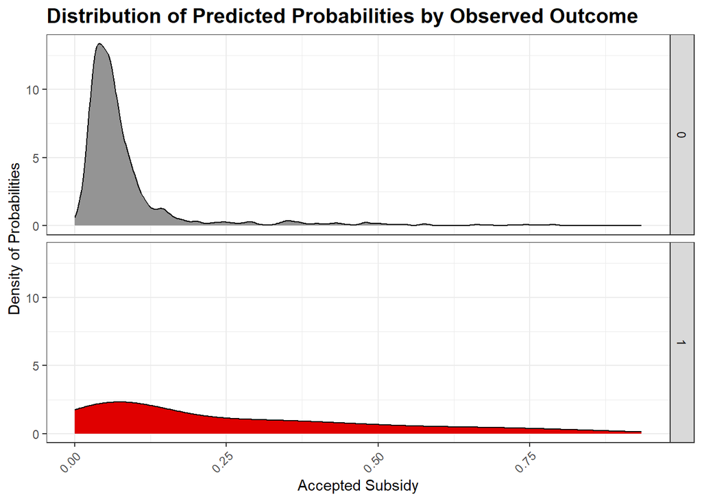

```r
testProbs <- data.frame(Outcome = as.factor(subsidytest$y_numeric),
                        Probs = predict(kitchensink, subsidytest, type= "response"))

ggplot(testProbs, aes(x = Probs, fill = as.factor(Outcome))) +
  geom_density() +
  facet_grid(Outcome ~ .) +
  scale_fill_manual(values = paletteV4) +
  labs(x = "Accepted Subsidy", y = "Density of Probabilities",
       title = "Distribution of Predicted Probabilities by Observed Outcome") +
  theme_bw()+
  theme(legend.position = "none",
        axis.text.x = element_text(angle = 45, hjust = 1),
        plot.subtitle = element_text(size = 12,face = "italic"),
        plot.title = element_text(size = 14.5, face = "bold"))
```

## Kitchen Sink Confusion Matrix

The confusion matrix reveals the model’s predictive performance in categorizing instances into two classes, “0” and “1,” representing the refusal and acceptance of subsidy credits, respectively.

```r
testProbskit <- testProbs %>%
  mutate(predOutcome  = as.factor(ifelse(testProbs$Probs > 0.5 , 1, 0)))

caret::confusionMatrix(testProbskit$predOutcome, testProbskit$Outcome,
                       positive = "1")
```

```
## Confusion Matrix and Statistics
##
##           Reference
## Prediction    0    1
##          0 1181   88
##          1   18   18
##
##                Accuracy : 0.9188
##                  95% CI : (0.9026, 0.933)
##     No Information Rate : 0.9188
##     P-Value [Acc > NIR] : 0.5258
##
##                   Kappa : 0.2215
##
##  Mcnemar's Test P-Value : 2.058e-11
##
##             Sensitivity : 0.16981
##             Specificity : 0.98499
##          Pos Pred Value : 0.50000
##          Neg Pred Value : 0.93065
##              Prevalence : 0.08123
##          Detection Rate : 0.01379
##    Detection Prevalence : 0.02759
##       Balanced Accuracy : 0.57740
##
##        'Positive' Class : 1
##
```

The model demonstrates a high specificity (0.98) in correctly identifying homeowners who are unlikely to accept the subsidy. However, its sensitivity (0.17) is relatively low, indicating a need for improvement in recognizing potential participants. Overall accuracy stands at 0.92, suggesting a generally reliable performance in distinguishing acceptance and refusal cases within the housing subsidy dataset. Further adjustments to enhance sensitivity could provide a more comprehensive understanding of the factors influencing homeowner decisions regarding the subsidy.

## Engineered Features Regression

In the case of the feature engineered model, the McFadden score has improved to 0.25, suggesting that our engineered model explains 25% of the variability in homeowners’ decisions regarding housing credits, specifically the acceptance or refusal of subsidy credits.

```r
# Engineered Model: Manipulated Features and Extracting Original Data

regressionengineered <- glm(y_numeric ~ .,
                  data=subsidytrain %>% dplyr::select(-X, -y),
                  family="binomial" (link="logit")) %>%
                  na.omit()

summary(regressionengineered)
```

```
##
## Call:
## glm(formula = y_numeric ~ ., family = binomial(link = "logit"),
##     data = subsidytrain %>% dplyr::select(-X, -y))
##
## Coefficients: (10 not defined because of singularities)
##                                Estimate Std. Error z value Pr(>|z|)
## (Intercept)                   7.466e+01  1.607e+02   0.464 0.642308
## age                           1.088e-02  1.279e-02   0.850 0.395189
## jobblue-collar               -3.523e-01  2.624e-01  -1.343 0.179327
## jobentrepreneur              -4.465e-01  4.422e-01  -1.010 0.312557
## jobhousemaid                 -1.622e-01  4.497e-01  -0.361 0.718330
## jobmanagement                -5.676e-01  2.967e-01  -1.913 0.055761 .
## jobretired                   -3.982e-01  3.800e-01  -1.048 0.294664
## jobself-employed             -4.017e-01  3.999e-01  -1.004 0.315222
## jobservices                  -1.302e-01  2.782e-01  -0.468 0.639721
## jobstudent                    1.407e-01  4.158e-01   0.338 0.735042
## jobtechnician                -2.831e-02  2.315e-01  -0.122 0.902669
## jobunemployed                 1.108e-01  3.781e-01   0.293 0.769484
## jobunknown                   -5.143e-01  6.708e-01  -0.767 0.443231
## maritalmarried                2.567e-01  2.425e-01   1.058 0.289883
## maritalsingle                 3.255e-01  2.790e-01   1.167 0.243394
## maritalunknown               -1.264e+01  4.959e+02  -0.025 0.979664
## educationbasic.6y             1.413e-01  3.881e-01   0.364 0.715733
## educationbasic.9y             7.772e-02  3.117e-01   0.249 0.803082
## educationhigh.school         -1.673e-02  3.006e-01  -0.056 0.955621
## educationilliterate          -1.416e+01  1.455e+03  -0.010 0.992240
## educationprofessional.course  1.350e-01  3.281e-01   0.411 0.680777
## educationuniversity.degree    5.159e-02  3.010e-01   0.171 0.863937
## educationunknown              1.765e-01  3.815e-01   0.463 0.643545
## taxLienunknown                1.075e-01  2.038e-01   0.528 0.597799
## taxLienyes                   -1.218e+01  1.455e+03  -0.008 0.993323
## mortgageunknown              -6.475e-01  6.045e-01  -1.071 0.284163
## mortgageyes                  -1.945e-02  1.374e-01  -0.142 0.887412
## taxbill_in_phlyes             6.161e-02  1.875e-01   0.329 0.742399
## contacttelephone             -8.666e-01  2.784e-01  -3.112 0.001856 **
## monthaug                      8.984e-02  4.198e-01   0.214 0.830525
## monthdec                     -9.637e-02  7.451e-01  -0.129 0.897094
## monthjul                     -1.220e-01  4.010e-01  -0.304 0.760949
## monthjun                      7.418e-02  4.517e-01   0.164 0.869557
```

[output cut: 32 more lines]

```
## Jobs_GroupedWhite Collar             NA         NA      NA       NA
## Jobs_GroupedWorking Class            NA         NA      NA       NA
## inflation_levellow           -5.795e+00  3.492e+00  -1.659 0.097086 .
## unemployment_levellow        -2.005e+00  1.246e+00  -1.608 0.107790
## ---
## Signif. codes:  0 '***' 0.001 '**' 0.01 '*' 0.05 '.' 0.1 ' ' 1
##
## (Dispersion parameter for binomial family taken to be 1)
##
##     Null deviance: 2089.8  on 2812  degrees of freedom
## Residual deviance: 1577.1  on 2754  degrees of freedom
##   (1 observation deleted due to missingness)
## AIC: 1695.1
##
## Number of Fisher Scoring iterations: 14
```

```r
kable(pR2(regressionengineered),
       caption = "Optimal Threshold") %>% kable_styling()
```

```
## fitting null model for pseudo-r2
```

|  | x |
| --- | --- |
| llh | -788.5384813 |
| llhNull | -1044.9218220 |
| G2 | 512.7666813 |
| McFadden | 0.2453613 |
| r2ML | 0.1666359 |
| r2CU | 0.3178383 |

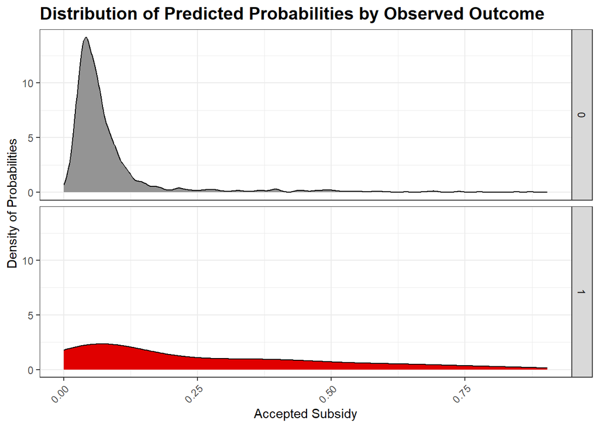

```r
testProbsfeature <- data.frame(Outcome = as.factor(subsidytest$y_numeric),
                        Probs = predict(regressionengineered, subsidytest, type= "response"))

ggplot(testProbsfeature, aes(x = Probs, fill = as.factor(Outcome))) +
  geom_density() +
  facet_grid(Outcome ~ .) +
  scale_fill_manual(values = paletteV4) +
  labs(x = "Accepted Subsidy", y = "Density of Probabilities",
       title = "Distribution of Predicted Probabilities by Observed Outcome") +
  theme_bw()+
  theme(legend.position = "none",
        axis.text.x = element_text(angle = 45, hjust = 1),
        plot.subtitle = element_text(size = 12,face = "italic"),
        plot.title = element_text(size = 14.5, face = "bold"))
```

## Engineered Features Confusion Matrix

```r
testProbsfeature_conf <-
  testProbsfeature %>%
  mutate(predOutcome  = as.factor(ifelse(testProbsfeature$Probs >  0.5 , 1, 0)))

caret::confusionMatrix(testProbsfeature_conf$predOutcome, testProbsfeature_conf$Outcome,
                       positive = "1")
```

```
## Confusion Matrix and Statistics
##
##           Reference
## Prediction    0    1
##          0 1177   88
##          1   22   18
##
##                Accuracy : 0.9157
##                  95% CI : (0.8993, 0.9302)
##     No Information Rate : 0.9188
##     P-Value [Acc > NIR] : 0.6798
##
##                   Kappa : 0.2115
##
##  Mcnemar's Test P-Value : 5.736e-10
##
##             Sensitivity : 0.16981
##             Specificity : 0.98165
##          Pos Pred Value : 0.45000
##          Neg Pred Value : 0.93043
##              Prevalence : 0.08123
##          Detection Rate : 0.01379
##    Detection Prevalence : 0.03065
##       Balanced Accuracy : 0.57573
##
##        'Positive' Class : 1
##
```

The model’s specificity of 0.98 signifies its strong capability in correctly identifying individuals who are unlikely to accept the housing subsidy. Conversely, its sensitivity of 0.17 indicates the need for improved recognition of potential participants. The overall accuracy of 0.92 demonstrates the model’s consistent performance in distinguishing cases of acceptance and refusal within the housing subsidy dataset. Further refinements to enhance the model’s sensitivity could yield a more comprehensive understanding of the underlying factors influencing homeowner decisions regarding the subsidy.

# **ROC CURVE**

The ROC curve for the kitchen sink and feature engineered models show a reliable ability to distinguish between positive and negative cases, as evident from the AUC score of 0.73. This high AUC value suggests that the feature engineered model performs notably better than random guessing in identifying positive cases (e.g., homeowners likely to accept the subsidy) and negative cases (e.g., homeowners unlikely to accept the subsidy).

[figure not shown]

```r
ggplot(testProbsfeature_conf, aes(d = as.numeric(Outcome), m = Probs)) +
  geom_roc(n.cuts = 50, labels = FALSE, colour = "#949494") +
  style_roc(theme = theme_grey) +
  geom_abline(slope = 1, intercept = 0, size = 1.5, color = "#E00000") +
  labs(title = "ROC Curve - Kitchen Sink Model") +
  theme_bw()+
  theme(legend.position = "none",
        axis.text.x = element_text(angle = 45, hjust = 1),
        plot.subtitle = element_text(size = 12,face = "italic"),
        plot.title = element_text(size = 14.5, face = "bold"))
```

```r
kbl(auc(testProbsfeature_conf$Outcome, testProbsfeature_conf$Probs), caption = "Optimal Threshold") %>%
  kable_styling(bootstrap_options = "striped", full_width = F, position = "left")
```

| x |
| --- |
| 0.7262656 |

[figure not shown]

```r
ggplot(testProbskit, aes(d = as.numeric(Outcome), m = Probs)) +
  geom_roc(n.cuts = 50, labels = FALSE, colour = "#E00000") +
  style_roc(theme = theme_grey) +
  geom_abline(slope = 1, intercept = 0, size = 1.5, color = 'grey') +
  labs(title = "ROC Curve - Feature Engineered Model") +
  theme_bw()+
  theme(legend.position = "none",
        axis.text.x = element_text(angle = 45, hjust = 1),
        plot.subtitle = element_text(size = 12,face = "italic"),
        plot.title = element_text(size = 14.5, face = "bold"))
```

```r
kbl(auc(testProbskit$Outcome, testProbskit$Probs), caption = "Optimal Threshold") %>%
  kable_styling(bootstrap_options = "striped", full_width = F, position = "left")
```

| x |
| --- |
| 0.7318205 |

# **CROSS VALIDATION**

```r
ctrl <- trainControl(method = "cv", number = 100, classProbs=TRUE, summaryFunction=twoClassSummary)

cvFit_kit <- train(y ~ .,
                  data=housingsubsidy %>%
                    dplyr::select(-X, -y_numeric,-Season, -Age, -Education, -Contact, -inflation_level,-unemployment_level, -Jobs_Grouped),
                method="glm", family="binomial",
                metric="ROC", trControl = ctrl)

cvFit_kit
```

```
## Generalized Linear Model
##
## 4119 samples
##   19 predictor
##    2 classes: 'no', 'yes'
##
## No pre-processing
## Resampling: Cross-Validated (100 fold)
## Summary of sample sizes: 4077, 4078, 4077, 4078, 4077, 4077, ...
## Resampling results:
##
##   ROC        Sens       Spec
##   0.7612564  0.9814264  0.215
```

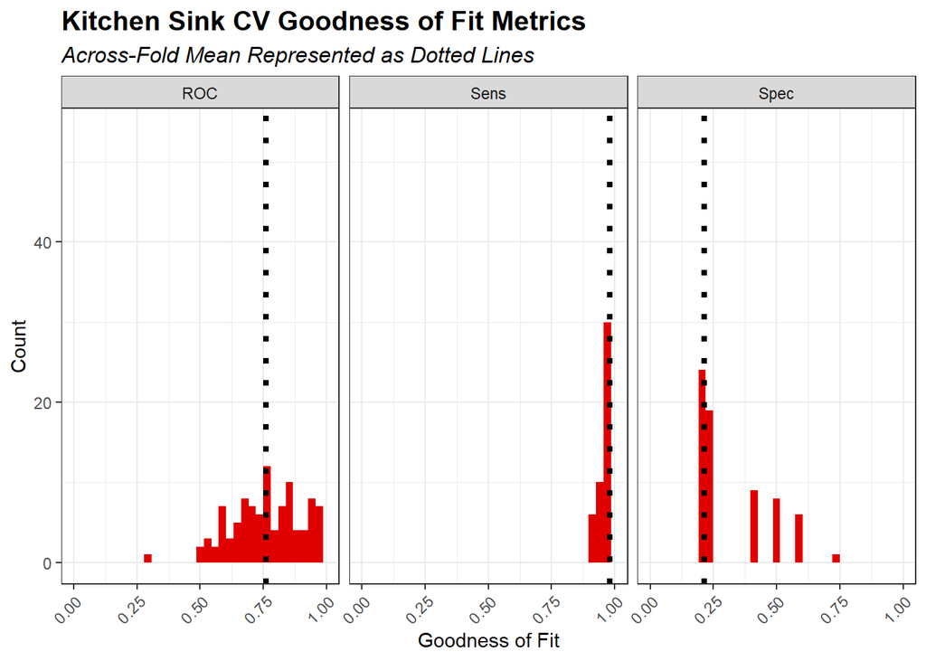

```r
dplyr::select(cvFit_kit$resample, -Resample) %>%
  gather(metric, value) %>%
  left_join(gather(cvFit_kit$results[2:4], metric, mean)) %>%
  ggplot(aes(value)) +
    geom_histogram(bins=35, fill = "#E00000") +
    facet_wrap(~metric) +
    geom_vline(aes(xintercept = mean), colour = "#000000", linetype = 3, size = 1.5) +
    scale_x_continuous(limits = c(0, 1)) +
    labs(x="Goodness of Fit", y="Count", title="Kitchen Sink CV Goodness of Fit Metrics",
         subtitle = "Across-Fold Mean Represented as Dotted Lines") +
    theme_bw() +
    theme(legend.position = "none",
        axis.text.x = element_text(angle = 45, hjust = 1),
        plot.subtitle = element_text(size = 12,face = "italic"),
        plot.title = element_text(size = 14.5, face = "bold"))
```

```r
ctrl <- trainControl(method = "cv", number = 100, classProbs=TRUE, summaryFunction=twoClassSummary)

cvFit_feat <- train(y ~ .,
                  data=housingsubsidy %>%
                    na.omit() %>%
                    dplyr::select(-X, -y_numeric, -month, -age, -marital),
                method="glm", family="binomial",
                metric="ROC", trControl = ctrl)

cvFit_feat
```

```
## Generalized Linear Model
##
## 4118 samples
##   23 predictor
##    2 classes: 'no', 'yes'
##
## No pre-processing
## Resampling: Cross-Validated (100 fold)
## Summary of sample sizes: 4076, 4077, 4076, 4076, 4076, 4077, ...
## Resampling results:
##
##   ROC        Sens       Spec
##   0.7662237  0.9809234  0.2225
```

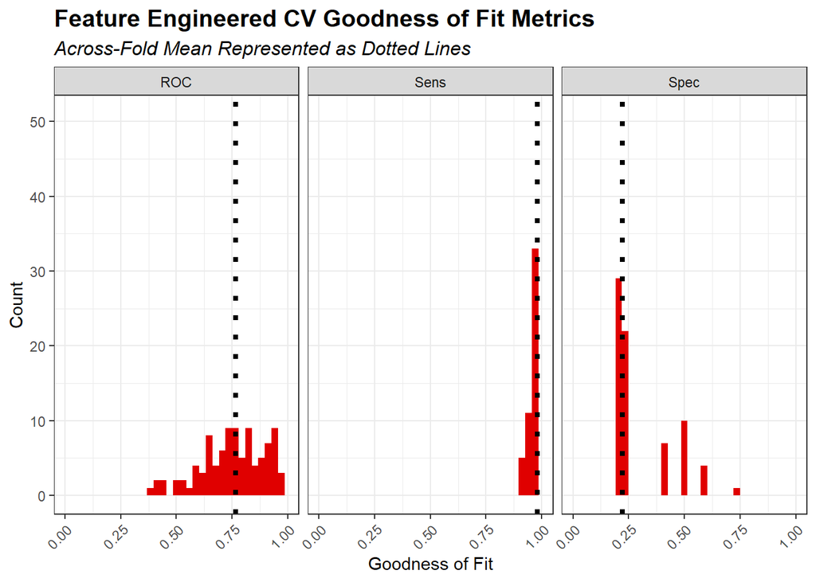

```r
dplyr::select(cvFit_feat$resample, -Resample) %>%
  gather(metric, value) %>%
  left_join(gather(cvFit_feat$results[2:4], metric, mean)) %>%
  ggplot(aes(value)) +
    geom_histogram(bins=35, fill = "#E00000") +
    facet_wrap(~metric) +
    geom_vline(aes(xintercept = mean), colour = "#000000", linetype = 3, size = 1.5) +
    scale_x_continuous(limits = c(0, 1)) +
    labs(x="Goodness of Fit", y="Count", title="Feature Engineered CV Goodness of Fit Metrics",
         subtitle = "Across-Fold Mean Represented as Dotted Lines") +
    theme_bw() +
    theme(legend.position = "none",
        axis.text.x = element_text(angle = 45, hjust = 1),
        plot.subtitle = element_text(size = 12,face = "italic"),
        plot.title = element_text(size = 14.5, face = "bold"))
```

# **COST BENEFIT ANALYSIS**

To conclude, we conduct a comprehensive cost-benefit analysis aimed at optimizing resource allocation and strategically guiding our subsidy campaign. Ultimately, our objective is establishing a threshold for categorizing individuals as probable candidates of accepting the tax credit. In this process, we approach the calculations from the perspective of the Department of Housing and Community Development, ensuring a delicate balance between cost savings and enhancing program participation. This approach will help us make informed decisions and maximize the impact of our tax credit initiative.

Our four assumptions when creating the cost-benefit analysis include:

- **1. The Premium Per House That Accepts The Subsidy is $10,000.**
- **2. There Is A Marketing Cost Of $2,850 For Each Contact.**
- **3. A $5,000 Subsidy Is Awarded Per House That Accepts.**
- **4. The Percentage Of Homeowners Who Accept The Subsidy Is 25%.**

To calculate the cost-benefit analysis, we use the following equations and methods:

**True Negative**: Predicted correctly the homeowner would not take the credit; no marketing resources were allocated; and no credit was allocated. Therefore, the equation would be (Count * 0).

**False Negative**: “Predicted the homeowner would not take the credit but they did; suggesting they signed up for reasons unrelated to the marketing campaign.” Our equation is (Count * 0).

**False Positive**: Predicted incorrectly the homeowner would take the credit; allocated marketing resources; no credit allocated.” Therefore, we would use (Count * -2850).

```r
#Creating A Cost Benefit Table

cost_benefit_table <-
   testProbsfeature_conf %>%
      count(predOutcome, Outcome) %>%
      summarize(True_Negative = sum(n[predOutcome==0 & Outcome==0]),
                True_Positive = sum(n[predOutcome==1 & Outcome==1]),
                False_Negative = sum(n[predOutcome==0 & Outcome==1]),
                False_Positive = sum(n[predOutcome==1 & Outcome==0])) %>%
      gather(Variable, Count) %>%
      mutate(Revenue =
                case_when(Variable == "True_Negative"  ~ Count * 0,
                         Variable == "True_Positive"  ~ ((Count * .25) * 58150),
                         Variable == "False_Negative" ~ Count * 0,
                         Variable == "False_Positive" ~ (Count * -2850))) %>%
      bind_cols(data.frame(Description = c(
               "Predicted correctly homeowner would not take the credit; no marketing resources were allocated; and no credit was allocated.",
               "Predicted correctly homeowner would take the credit; allocated the marketing resources; and 25% accepted the credit.",
               "Predicted that a homeowner would not take the credit but they did; signed up for reasons unrelated to the marketing campaign.",
               "Predicted incorrectly homeowner would take the credit; allocated marketing resources; no credit allocated.")))

kable(cost_benefit_table) %>%
  kable_styling(font_size = 12, full_width = F,
                bootstrap_options = c("striped", "hover", "condensed")) %>%
  footnote(general_title = "\n",
           general = "")
```

| Variable | Count | Revenue | Description |
| --- | --- | --- | --- |
| True_Negative | 1177 | 0 | Predicted correctly homeowner would not take the credit; no marketing resources were allocated; and no credit was allocated. |
| True_Positive | 18 | 261675 | Predicted correctly homeowner would take the credit; allocated the marketing resources; and 25% accepted the credit. |
| False_Negative | 88 | 0 | Predicted that a homeowner would not take the credit but they did; signed up for reasons unrelated to the marketing campaign. |
| False_Positive | 22 | -62700 | Predicted incorrectly homeowner would take the credit; allocated marketing resources; no credit allocated. |

The decision-making process should evaluate both business and public interest perspectives. From a business standpoint, a housing subsidy or credit program offers numerous advantages. Firstly, it can stimulate demand in the real estate market, boosting home sales and construction. This increased activity benefits developers and builders while contributing to overall economic growth and job creation in the construction sectors. Additionally, these programs have the potential to enhance property values, promote neighborhood revitalization, and create vibrant communities. This, in turn, can positively impact local businesses by increasing foot traffic and expanding their customer base. Overall, a housing subsidy program can yield both direct and indirect economic benefits, making it a valuable consideration from a business perspective.

```r
iterateThresholds <- function(data) {
  x = .01
  all_prediction <- data.frame()
  while (x <= 1) {

  this_prediction <-
      testProbsfeature_conf %>%
      mutate(predOutcome = ifelse(Probs > x, 1, 0)) %>%
      count(predOutcome, Outcome) %>%
      summarize(True_Negative = sum(n[predOutcome==0 & Outcome==0]),
                True_Positive = sum(n[predOutcome==1 & Outcome==1]),
                False_Negative = sum(n[predOutcome==0 & Outcome==1]),
                False_Positive = sum(n[predOutcome==1 & Outcome==0])) %>%
     gather(Variable, Count) %>%
     mutate(Revenue =
               ifelse(Variable == "True_Negative", Count * 0,
               ifelse(Variable == "True_Positive", (-2850 + 0.25 *(10000 + 56000 -5000)) * Count,
               ifelse(Variable == "False_Negative", Count * 0,
               ifelse(Variable == "False_Positive", (-2850) * Count, 0)))),
            Threshold = x)

  all_prediction <- rbind(all_prediction, this_prediction)
  x <- x + .01
  }
return(all_prediction)
}
```

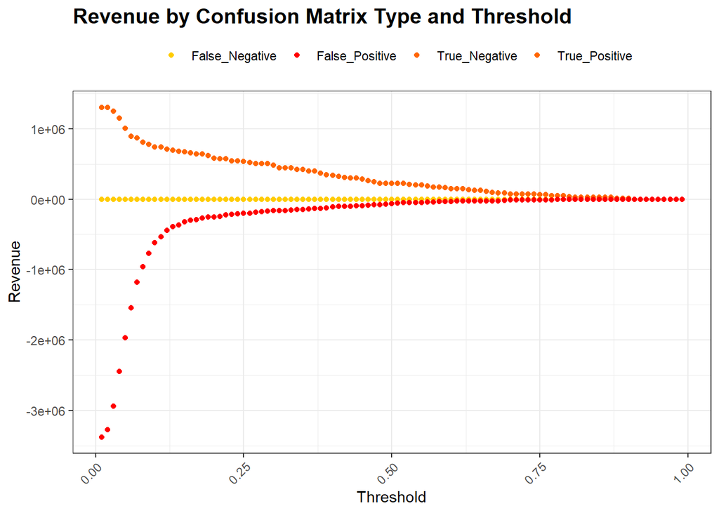

```r
whichThreshold <- iterateThresholds(testProbsfeature_conf)

whichThreshold_revenue <-
whichThreshold %>%
    group_by(Threshold) %>%
    summarize(Revenue = sum(Revenue))

whichThreshold %>%
  ggplot(.,aes(Threshold, Revenue, colour = Variable)) +
  geom_point() +
  scale_colour_manual(values = paletteV1[c(5, 1:3)]) +
  labs(title = "Revenue by Confusion Matrix Type and Threshold",
       y = "Revenue") +
  guides(colour = guide_legend(title = "")) +
  theme_bw() +
  theme(legend.position = "top",
        axis.text.x = element_text(angle = 45, hjust = 1),
        plot.subtitle = element_text(size = 12,face = "italic"),
        plot.title = element_text(size = 14.5, face = "bold"))
```

```r
whichThreshold_revenue <-
  whichThreshold %>%
    mutate(TookCredit = ifelse(Variable == "True_Positive", (Count * .25),
                         ifelse(Variable == "False_Negative", Count, 0))) %>%
  group_by(Threshold) %>%
    summarize(Total_Revenue = sum(Revenue),
              Total_Count_Of_Credits = sum(TookCredit))
```

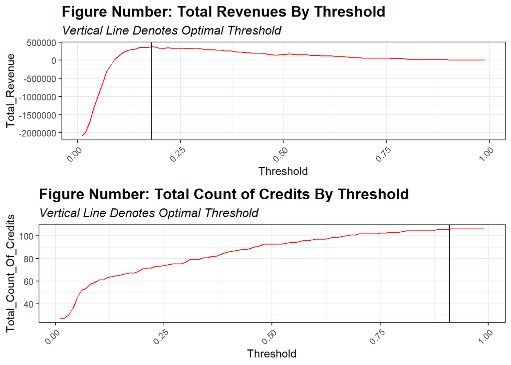

```r
grid.arrange(
  ncol = 1,
  ggplot(whichThreshold_revenue) +
    geom_line(aes(x = Threshold, y = Total_Revenue, color = "red")) +
    geom_vline(xintercept = pull(arrange(whichThreshold_revenue, -Total_Revenue)[1, 1]), color = "Black") +
    labs(title = "Figure Number: Total Revenues By Threshold",
         subtitle = "Vertical Line Denotes Optimal Threshold") +
    scale_color_manual(values = c("red" = "red")) +
    theme_bw() +
    theme(legend.position = "none",
          axis.text.x = element_text(angle = 45, hjust = 1),
          plot.subtitle = element_text(size = 12, face = "italic"),
          plot.title = element_text(size = 14.5, face = "bold")),

  ggplot(whichThreshold_revenue) +
    geom_line(aes(x = Threshold, y = Total_Count_Of_Credits, color = "red")) +
    geom_vline(xintercept = pull(arrange(whichThreshold_revenue, -Total_Count_Of_Credits)[1, 1]), color = "Black")+
    labs(title = "Figure Number: Total Count of Credits By Threshold",
         subtitle = "Vertical Line Denotes Optimal Threshold") +
    scale_color_manual(values = c("red" = "red")) +
    theme_bw() +
    theme(legend.position = "none",
          axis.text.x = element_text(angle = 45, hjust = 1),
          plot.subtitle = element_text(size = 12, face = "italic"),
          plot.title = element_text(size = 14.5, face = "bold")))
```

```r
optimalthreshold <- whichThreshold_revenue %>%
  mutate(Threshold = Threshold * 100) %>%
  dplyr::select(Threshold, Total_Revenue, Total_Count_Of_Credits)

filtered_data <- optimalthreshold %>%
  filter(Threshold == '21' | Threshold == '50')

kable(filtered_data,
       caption = "Optimal Threshold") %>% kable_styling()
```

| Threshold | Total_Revenue | Total_Count_Of_Credits |
| --- | --- | --- |
| 21 | 325300 | 71.5 |
| 50 | 160500 | 92.5 |

# **CONCLUSION**

While the model’s predictive abilities regarding homeowner acceptance of housing subsidies may not be fully proficient, it should still be regarded as a valuable starting point for future exploration and refinement. The model’s commendable accuracy, demonstrated generalizability, and its ability to reliably identify individuals unlikely to accept the housing subsidy contribute to the establishment of a strong foundational framework for predictive analysis in the domain of housing subsidies. Moreover, through further data gathering and refinement of the model’s feature, a deeper and more comprehensive understanding of the intricate factors influencing homeowner decisions regarding the subsidy can be achieved so HED can run a more efficient marketing campaign.

In summary, the analysis of Emil City’s Housing and Community Development Department’s home repair tax credit program has provided valuable insights into its effectiveness and factors influencing homeowner participation with a record of boosting property values and community benefits. Key findings include the influence of prior contact, economic stability, and categorical variables on subsidy acceptance. A balanced approach considering both financial and societal benefits is also crucial. The department should refine its outreach strategy focusing on likely subsidy recipients while maintaining a balance between cost savings and community welfare, necessitating ongoing program parameter monitoring and adjustment for long-term success.